# Question

A polynomial is sketched below.

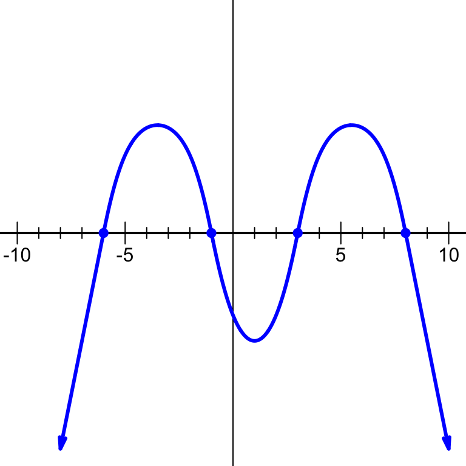

Which polynomial (in standard form) best matches the sketch?

## Answerlist

# Solution

If a polynomial has a factor of $(x-r)$, then there will be an $x$-intercept at $(r,0)$.

In this case, the roots (the $x$-intercepts) are at:

$$-6,\,-1,\,3,\,8$$

Thus, the factors are $x+6$ and $x+1$ and $x-3$ and $x-8$. So, we know that the function could be written as:

$$y=a(x+6)(x+1)(x-3)(x-8)$$

where $a$ is some constant.

Lastly, we need to determine whether $a$ should be positive or negative. In this problem, either $a=1$ or $a=-1$. To determine this, look at the right side of the graph. Specifically, we are considering the [end behavior of polynomials](https://www.khanacademy.org/math/algebra2/x2ec2f6f830c9fb89:poly-graphs/x2ec2f6f830c9fb89:poly-end-behavior/a/end-behavior-of-polynomials). Notice that once $x$ is larger than $8$, all the factors will be positive, so only $a$ will dictate whether the function on the right side is positive or negative.

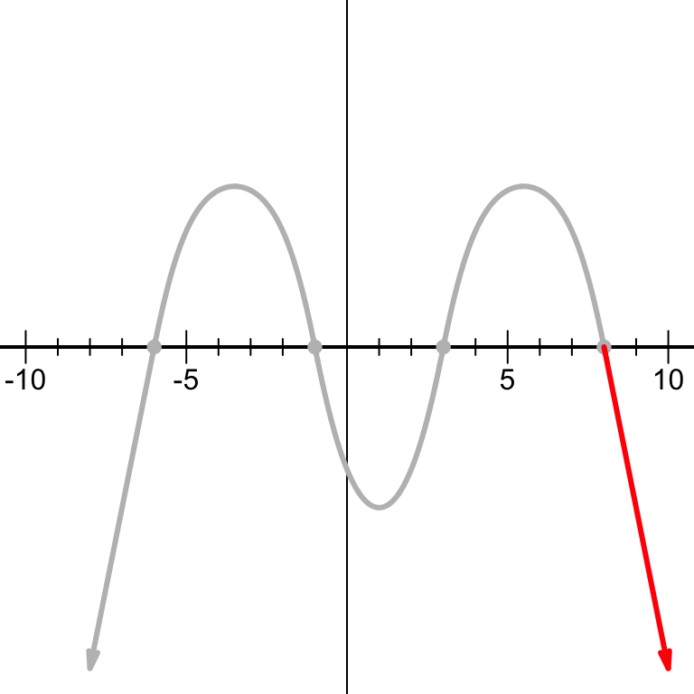

Notice, on the right side, the function is heading down. I guess more importantly, as $x\to \infty$ we see the function is negative. This implies that $a$ is negative. So, in this case, $a=-1$.

$$y=-(x+6)(x+1)(x-3)(x-8)$$

$$\begin{align*}
(x+a)(x+b)(x+c)(x+d) \equiv & ~ x^4 \\
& + (a+b+c+d)x^3 \\
& + (ab+ac+ad+bc+bd+cd)x^2 \\
& + (abc+abd+acd+bcd)x \\
& + abcd
\end{align*}$$

# Meta-information